# Homework 11

Solutions will be available after Monday, November 9, 2026.

## Question 1: Implementing K-means

K-means is a relatively simple algorithm that we can write ourselves. For Questions 1 and 2, do not use an existing function that performs K-means directly.

Generate 10 observations with two independent standard normal coordinates. Set a random seed and report it. Randomly assign the observations to $K=2$ clusters, making sure neither cluster is empty. Let $C(i)$ denote the cluster assigned to observation $x_i$, and let $m_k$ denote the mean of cluster $k$.

1. Perform one iteration: calculate the cluster means, then assign each observation to its closest mean using Euclidean distance. Report the means and updated assignments, and plot the observations colored by their updated assignments.
2. Write a function that repeats these two steps until the assignments stop changing or a specified maximum number of iterations is reached. Your function should work for a data matrix with any number of variables and a chosen number of clusters $K$. Start from a nonempty assignment to each cluster; if a cluster becomes empty during iteration, keep its previous mean. Recalculate the cluster means from the final assignments before returning them. Return the final assignments, cluster means, and within-cluster sum of squares,

   $$\sum_{k=1}^K\sum_{i:\,C(i)=k}\lVert x_i-m_k\rVert^2.$$
3. Apply your function to the same 10 observations from two different random initial assignments. Report the final plots, cluster means, and within-cluster sums of squares. Do the two runs produce the same grouping and objective value? Explain your findings.

### Solution: Question One

```r
set.seed(123)

X <- matrix(rnorm(20), nrow = 10, ncol = 2)

cluster <- sample(rep(1:2, each = 5))

means <- rbind(
  colMeans(X[cluster == 1, , drop = FALSE]),
  colMeans(X[cluster == 2, , drop = FALSE])
)

print(means)
```

```
           [,1]      [,2]
[1,]  0.6354249  0.566210
[2,] -0.4861736 -0.148966
```

```r
distances <- sapply(1:2, function(k) {
  rowSums((sweep(X, 2, means[k, ], "-"))^2)
})

updated_cluster <- max.col(-distances)

print(updated_cluster)
```

```
 [1] 1 2 1 2 2 1 1 2 2 2
```

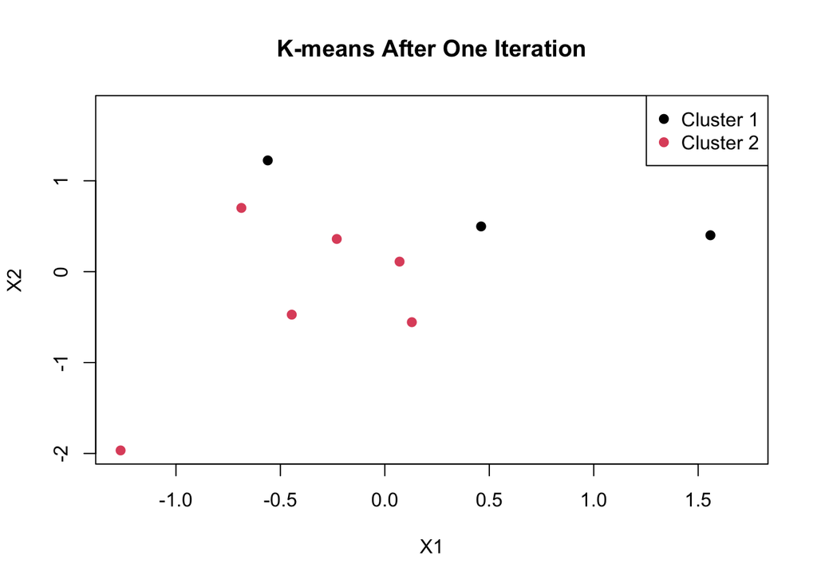

```r
plot(X, col = updated_cluster, pch = 19,
     xlab = "X1", ylab = "X2",
     main = "K-means After One Iteration")

legend("topright", legend = c("Cluster 1", "Cluster 2"),
       col = 1:2, pch = 19)
```

```r
my_kmeans <- function(X, K, cluster, max_iter = 100) {
  X <- as.matrix(X)

  means <- t(sapply(1:K, function(k) {
    colMeans(X[cluster == k, , drop = FALSE])
  }))

  for (iter in 1:max_iter) {

    distances <- sapply(1:K, function(k) {
      rowSums(sweep(X, 2, means[k, ], "-")^2)
    })

    new_cluster <- max.col(-matrix(distances, ncol = K))

    if (all(new_cluster == cluster)) break

    cluster <- new_cluster

    for (k in 1:K) {
      if (any(cluster == k)) {
        means[k, ] <- colMeans(X[cluster == k, , drop = FALSE])
      }
    }
  }

  for (k in 1:K) {
  if (any(cluster == k)) {
    means[k, ] <- colMeans(X[cluster == k, , drop = FALSE])
  }
}

  wcss <- sum(sapply(1:nrow(X), function(i) {
    sum((X[i, ] - means[cluster[i], ])^2)
  }))

  return(list(cluster = cluster, means = means, wcss = wcss))
}

set.seed(456)
cluster1 <- sample(rep(1:2, each = 5))

set.seed(789)
cluster2 <- sample(rep(1:2, each = 5))

result1 <- my_kmeans(X, 2, cluster1)
result2 <- my_kmeans(X, 2, cluster2)

print(result1$means)
```

```
           [,1]       [,2]
[1,] -0.4046596 -0.3038995
[2,]  0.7935535  0.9774042
```

```r
print(result1$wcss)
```

```
[1] 10.49981
```

```r
print(result2$means)
```

```
           [,1]       [,2]
[1,] -0.4046596 -0.3038995
[2,]  0.7935535  0.9774042
```

```r
print(result2$wcss)
```

```
[1] 10.49981
```

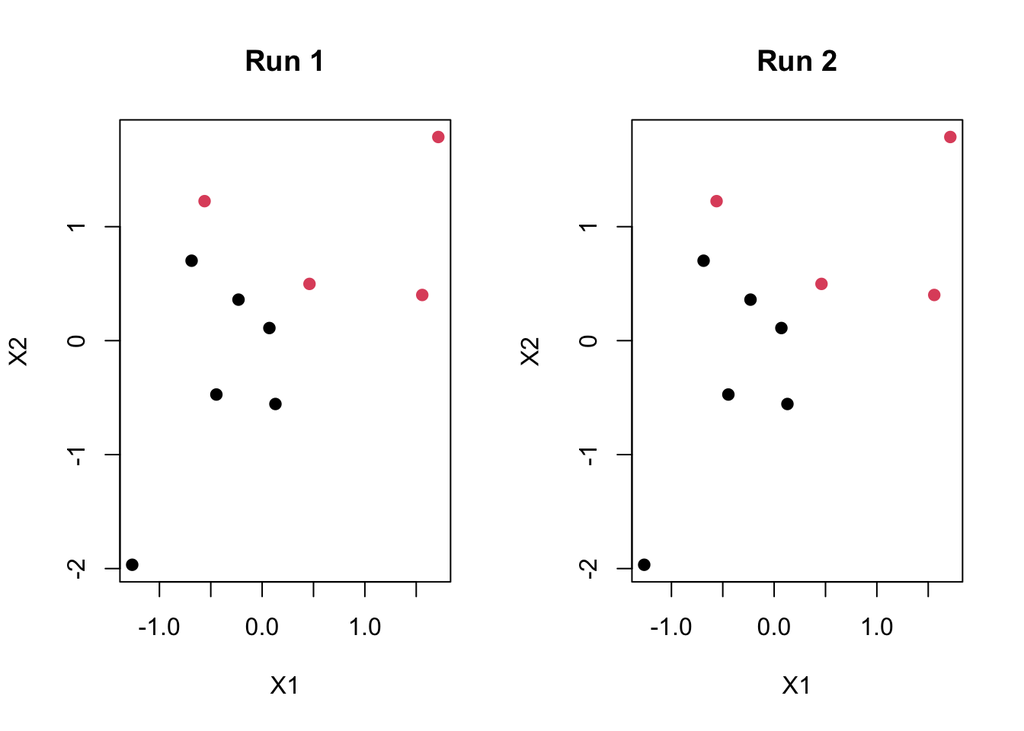

```r
par(mfrow = c(1, 2))

plot(X, col = result1$cluster, pch = 19,
     xlab = "X1", ylab = "X2",
     main = "Run 1")

plot(X, col = result2$cluster, pch = 19,
     xlab = "X1", ylab = "X2",
     main = "Run 2")
```

```r
par(mfrow = c(1, 1))
```

After calculating the means of the two initially assigned clusters, I reassigned each observation to the cluster with the closest mean using Euclidean distance. After one iteration, four observations were assigned to Cluster 1 and six observations were assigned to Cluster 2. The plot displays the updated assignments.

The function is written above.

Both runs produced the same cluster assignments, cluster means, and within-cluster sum of squares of 10.49981. Although the initial assignments were different, both runs converged to the same solution. This shows that different initial assignments can produce the same final clustering.

## Question 2: Image color compression

Pick your favorite color image and use your K-means function from Question 1 to cluster its pixels. For computational efficiency, resize the image to no more than $200\times200$ pixels and use its three RGB color channels.

1. Plot the original image and report its dimensions. Transform it into a data matrix with one observation per pixel and three variables: red, green, and blue. Report the dimensions of this matrix.
2. For $K=2,3,5,10$, apply your function to the pixel data. Report the cluster means and within-cluster sum of squares for each $K$. Reconstruct and plot each compressed image by replacing every pixel with its assigned cluster mean. Use the same RGB scale for all fits.
3. Which value of $K$ would you choose for this image? Briefly justify your choice using the reconstructed images and the within-cluster sums of squares.

### Solution: Question Two

```r
library(jpeg)

img <- readJPEG("parrot.jpeg")

rows <- dim(img)[1]
cols <- dim(img)[2]

new_rows <- round(rows * min(200 / rows, 200 / cols))
new_cols <- round(cols * min(200 / rows, 200 / cols))

row_idx <- round(seq(1, rows, length.out = new_rows))
col_idx <- round(seq(1, cols, length.out = new_cols))

img_small <- img[row_idx, col_idx, ]

pixels <- matrix(img_small, ncol = 3)

dim(pixels)
```

```
[1] 22400     3
```

```r
dim(img)
```

```
[1] 2208 1242    3
```

```r
dim(img_small)
```

```
[1] 200 112   3
```

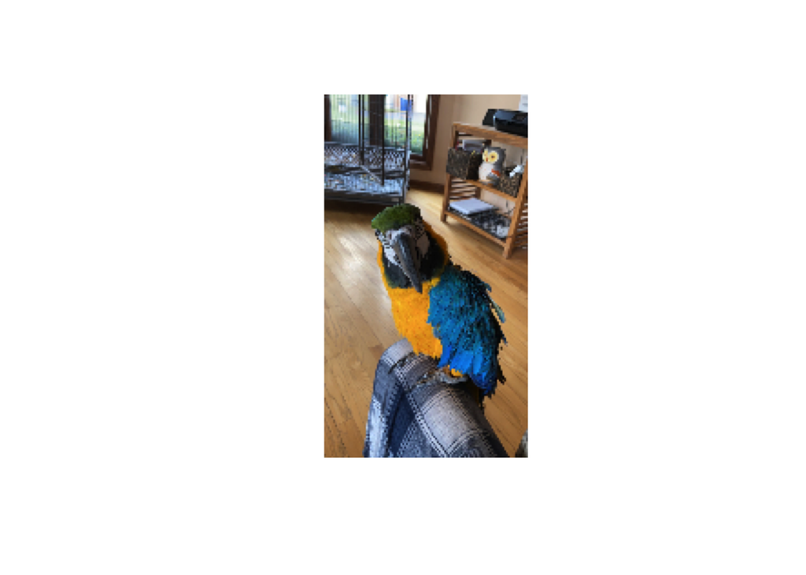

```r
plot(as.raster(img_small))
```

```r
set.seed(123)

K_values <- c(2, 3, 5, 10)
results <- list()

for (K in K_values) {
  initial <- sample(rep(1:K, length.out = nrow(pixels)))

  results[[as.character(K)]] <- my_kmeans(
    pixels, K, initial
  )
}

sapply(results, function(x) x$wcss)
```

```
        2         3         5        10
1695.3179 1134.2734  659.9324  300.5273
```

```r
lapply(results, function(x) round(x$means, 3))
```

```
$`2`
      [,1]  [,2]  [,3]
[1,] 0.215 0.255 0.279
[2,] 0.704 0.629 0.530

$`3`
      [,1]  [,2]  [,3]
[1,] 0.747 0.753 0.747
[2,] 0.191 0.239 0.269
[3,] 0.654 0.536 0.391

$`5`
      [,1]  [,2]  [,3]
[1,] 0.152 0.159 0.165
[2,] 0.754 0.758 0.749
[3,] 0.248 0.459 0.614
[4,] 0.399 0.352 0.313
[5,] 0.721 0.565 0.369

$`10`
       [,1]  [,2]  [,3]
 [1,] 0.117 0.242 0.348
 [2,] 0.127 0.116 0.104
 [3,] 0.907 0.636 0.148
 [4,] 0.026 0.456 0.696
 [5,] 0.807 0.808 0.790
 [6,] 0.400 0.443 0.507
 [7,] 0.619 0.467 0.311
 [8,] 0.317 0.271 0.229
 [9,] 0.746 0.618 0.465
[10,] 0.577 0.642 0.717
```

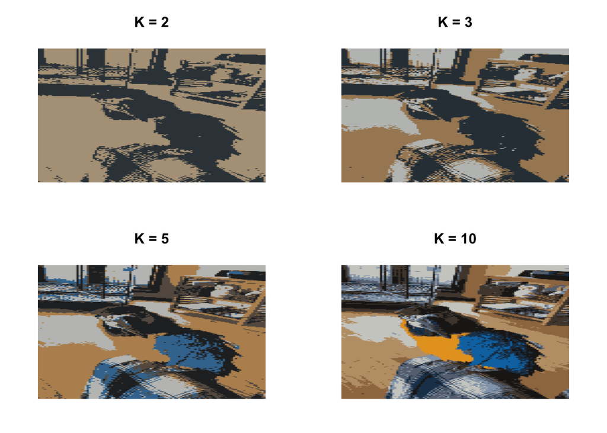

```r
par(mfrow = c(2, 2), mar = c(2, 2, 3, 2))

for (K in K_values) {
  result <- results[[as.character(K)]]

  compressed <- result$means[result$cluster, ]

  compressed_img <- array(compressed, dim = dim(img_small))

  plot.new()
  rasterImage(as.raster(compressed_img),
              0, 0, 1, 1)
  title(main = paste("K =", K))
}
```

```r
par(mfrow = c(1, 1))
```

I resized the original image and converted it into a matrix containing 22,400 observations and 3 variables representing the red, green, and blue values of each pixel.

I applied my K-means function using K = 2, 3, 5, and 10. As K increased, the within-cluster sum of squares decreased from 1695.32 to 300.53. The reconstructed images also became more detailed and closer to the original image.

I would choose K = 10 because it produces the most accurate colors and details. The parrot’s blue and yellow feathers are much easier to distinguish, and the within-cluster sum of squares is the lowest at 300.53.

## Question 3: Hierarchical clustering of cars

The file `data/mtcars.csv` contains 11 numerical variables for 32 cars, including fuel economy, horsepower, and weight. The `car` column gives the model names; use it to label observations, not as a clustering variable. You may use existing hierarchical clustering functions for this question.

1. Standardize each numerical variable to have mean 0 and standard deviation 1. Using Euclidean distance, perform hierarchical clustering with single, complete, and average linkage. Plot the three dendrograms with the car names and compare the results.
2. Choose one linkage method and a number of clusters that you consider reasonable. Report the cluster memberships and a table of cluster means on the original variable scales. Describe the main characteristics of the groups and explain your choice using the dendrogram and table. Briefly explain why standardizing the variables matters for this analysis.

### Solution: Question Three

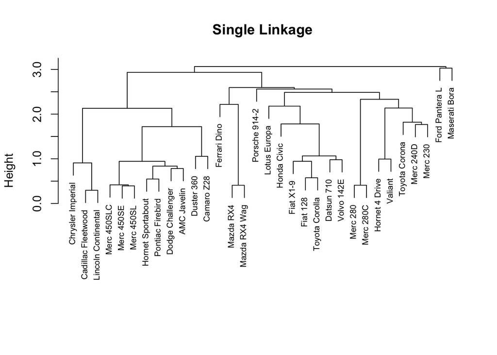

```r
cars <- read.csv("data/mtcars.csv")

rownames(cars) <- cars$car
cars$car <- NULL

cars_scaled <- scale(cars)

d <- dist(cars_scaled, method = "euclidean")

single <- hclust(d, method = "single")
complete <- hclust(d, method = "complete")
average <- hclust(d, method = "average")

plot(single, main = "Single Linkage",
     xlab = "", sub = "", cex = 0.7)
```

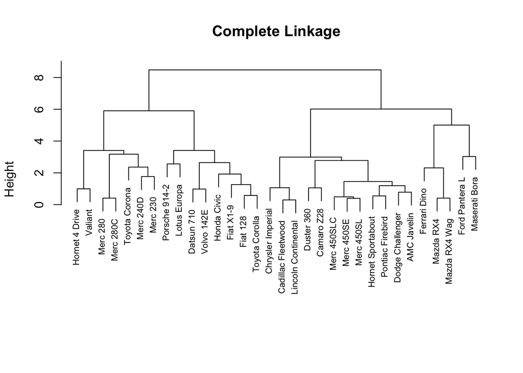

```r
plot(complete, main = "Complete Linkage",
     xlab = "", sub = "", cex = 0.7)
```

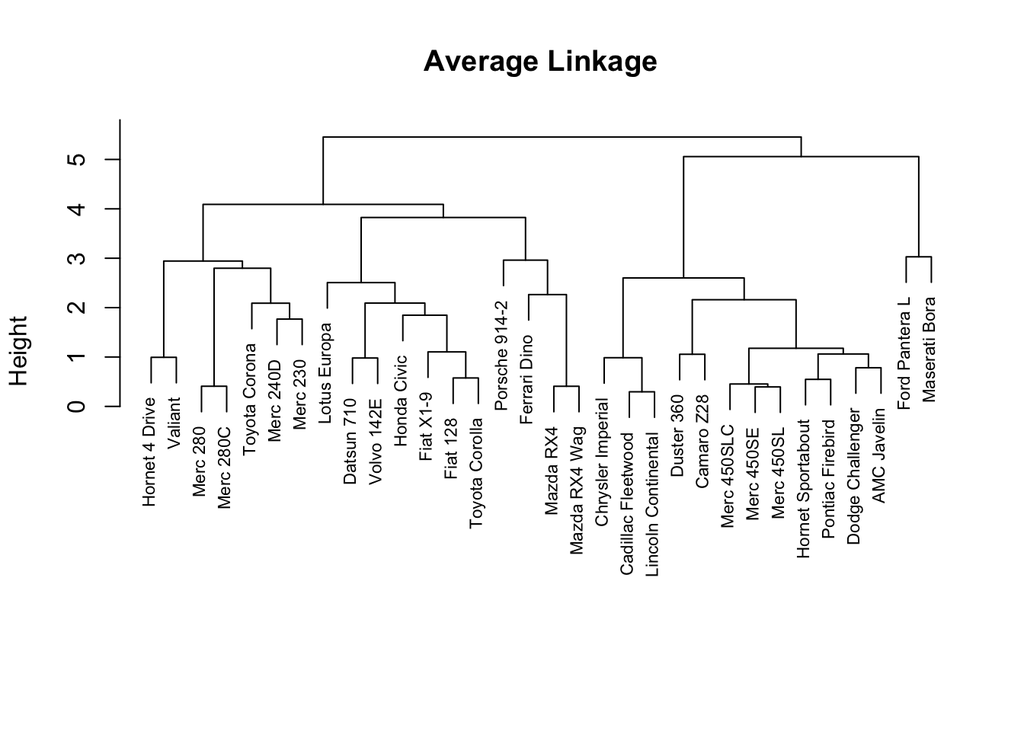

```r
plot(average, main = "Average Linkage",
     xlab = "", sub = "", cex = 0.7)
```

```r
groups <- cutree(complete, k = 3)

split(names(groups), groups)
```

```
$`1`
[1] "Mazda RX4"      "Mazda RX4 Wag"  "Ford Pantera L" "Ferrari Dino"
[5] "Maserati Bora"

$`2`
 [1] "Datsun 710"     "Hornet 4 Drive" "Valiant"        "Merc 240D"
 [5] "Merc 230"       "Merc 280"       "Merc 280C"      "Fiat 128"
 [9] "Honda Civic"    "Toyota Corolla" "Toyota Corona"  "Fiat X1-9"
[13] "Porsche 914-2"  "Lotus Europa"   "Volvo 142E"

$`3`
 [1] "Hornet Sportabout"   "Duster 360"          "Merc 450SE"
 [4] "Merc 450SL"          "Merc 450SLC"         "Cadillac Fleetwood"
 [7] "Lincoln Continental" "Chrysler Imperial"   "Dodge Challenger"
[10] "AMC Javelin"         "Camaro Z28"          "Pontiac Firebird"
```

```r
cluster_means <- aggregate(cars, by = list(Cluster = groups), FUN = mean)

print(round(cluster_means, 2))
```

```
  Cluster   mpg  cyl   disp     hp drat   wt  qsec   vs   am gear carb
1       1 18.50 6.80 223.40 198.80 3.84 3.00 15.62 0.00 1.00 4.60 5.20
2       2 24.65 4.53 131.65  91.33 3.90 2.58 19.16 0.93 0.53 3.93 1.80
3       3 15.05 8.00 357.62 194.17 3.12 4.10 17.14 0.00 0.00 3.00 3.08
```

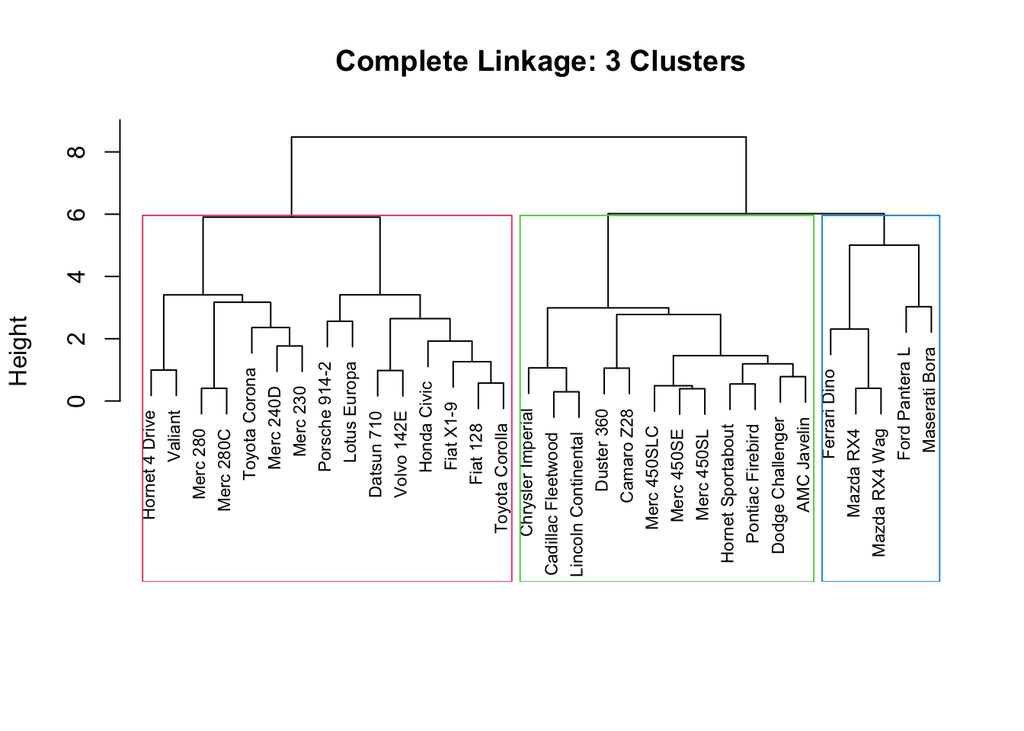

```r
plot(complete, main = "Complete Linkage: 3 Clusters",
     xlab = "", sub = "", cex = 0.7)

rect.hclust(complete, k = 3, border = 2:4)
```

I standardized the variables and performed hierarchical clustering using Euclidean distance with single, complete, and average linkage. Single linkage shows more chaining, with observations joining clusters gradually. Complete linkage produces more distinct groups, while average linkage falls between the two methods. The dendrograms show that the choice of linkage method affects how the cars are grouped.

I chose complete linkage with three clusters because the dendrogram shows relatively distinct groups. Cluster 1 contains cars with higher horsepower and manual transmissions. Cluster 2 contains lighter, more fuel-efficient cars with lower horsepower. Cluster 3 contains heavier cars with larger engines and lower fuel efficiency. These differences suggest that the clustering successfully groups cars with similar characteristics. Standardization is important because it prevents variables with larger numerical scales, such as displacement, from having too much influence on the clustering. This is because clustering uses Euclidean distance to measure distances between observations.